# A4

Brianny Martinez

Stacked bar:

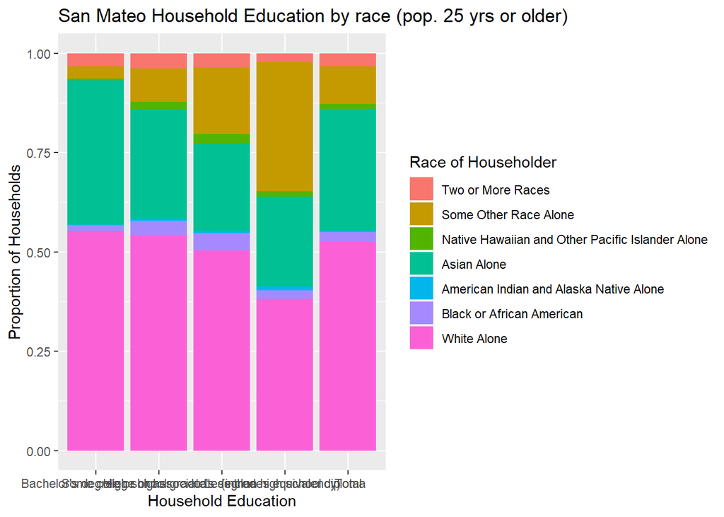

Filled bar:

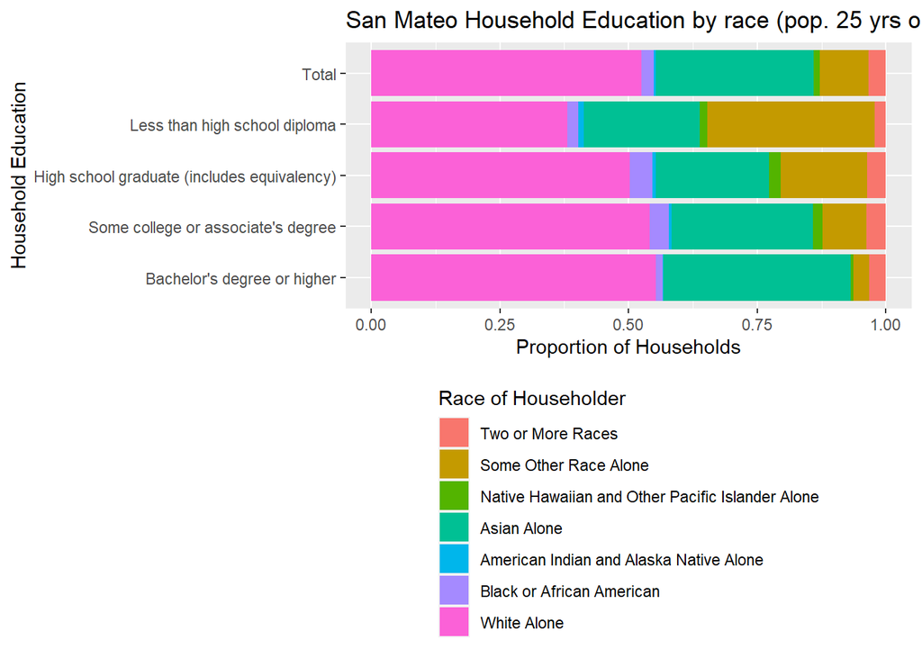

Is there disproportionate education attainment by race in the county?” Note that the universe of the ACS datasets on educational attainment is “population 25 years or older”, so be sure to clarify that in your visuals and commentary.

Stacked bar:

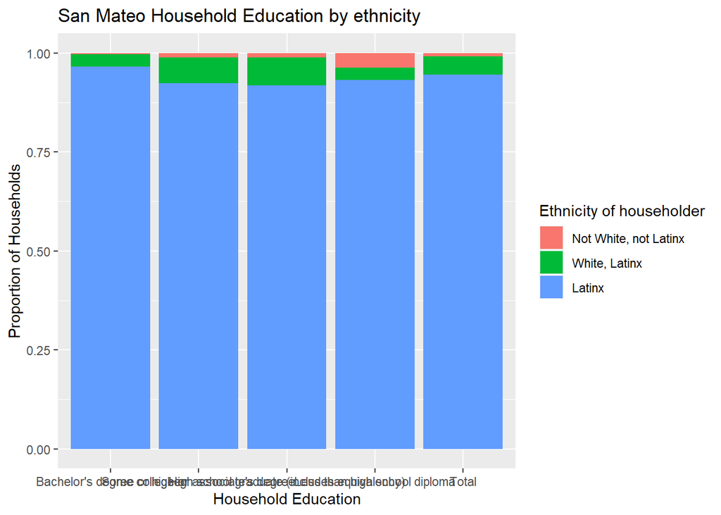

Filled bar:

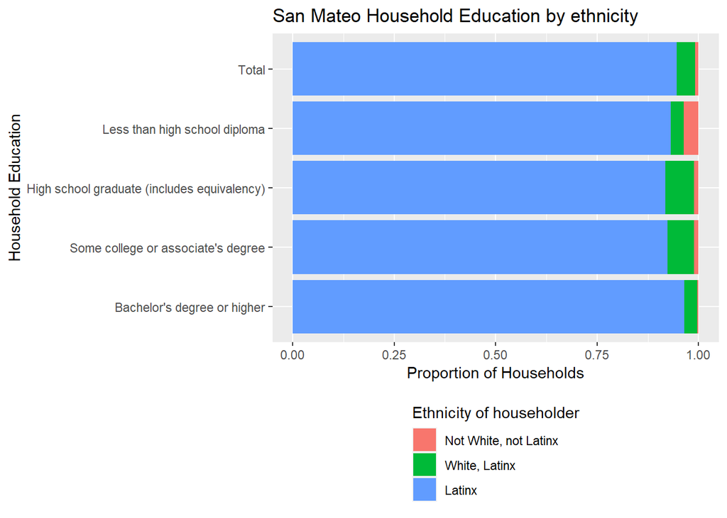

Comments: There is a large Latinx population in San Mateo county. Despite this, we can still see that there is some disproportions in education attainment with the “not white, not latinx” data. With this group, the larger proportion is in “less than high school diploma”. I think presenting the data this way can be misleading especially considering how Afro-latinx or indigenous latinx people face different circumstances and access to resources than White latinx people. Grouping into three categories reduces the amount of insights we are able to gain from the data.